# Week 1- Lab I

Amol Gote

09/06/2019

```r
source("http://www.openintro.org/stat/data/arbuthnot.R")
arbuthnot
```

```
##    year boys girls
## 1  1629 5218  4683
## 2  1630 4858  4457
## 3  1631 4422  4102
## 4  1632 4994  4590
## 5  1633 5158  4839
## 6  1634 5035  4820
## 7  1635 5106  4928
## 8  1636 4917  4605
## 9  1637 4703  4457
## 10 1638 5359  4952
## 11 1639 5366  4784
## 12 1640 5518  5332
## 13 1641 5470  5200
## 14 1642 5460  4910
```

[output cut: 68 more lines]

**Excercise 1**

What command would you use to extract just the counts of girls baptized?

```r
arbuthnot$girls
```

```
##  [1] 4683 4457 4102 4590 4839 4820 4928 4605 4457 4952 4784 5332 5200 4910
## [15] 4617 3997 3919 3395 3536 3181 2746 2722 2840 2908 2959 3179 3349 3382
## [29] 3289 3013 2781 3247 4107 4803 4881 5681 4858 4319 5322 5560 5829 5719
## [43] 6061 6120 5822 5738 5717 5847 6203 6033 6041 6299 6533 6744 7158 7127
## [57] 7246 7119 7214 7101 7167 7302 7392 7316 7483 6647 6713 7229 7767 7626
## [71] 7452 7061 7514 7656 7683 5738 7779 7417 7687 7623 7380 7288
```

**Excercise 2**

Is there an apparent trend in the number of girls baptized over the years? How would you describe it?

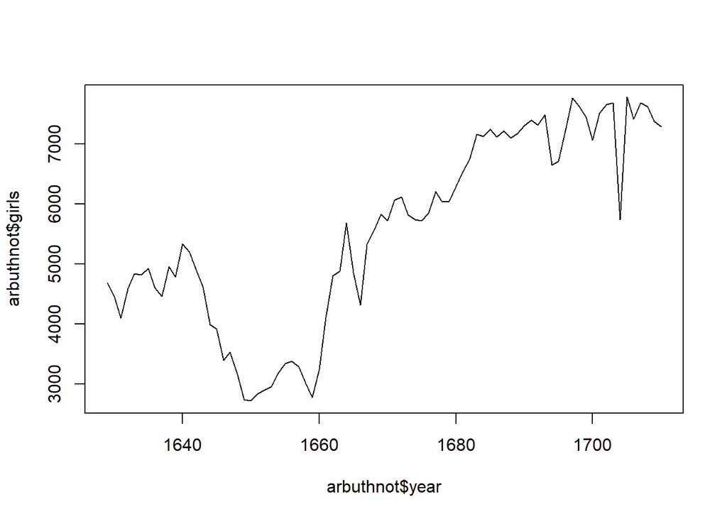

```r
plot(x = arbuthnot$year, y = arbuthnot$girls, type = "l")
```

Answer:

1. Number of girls baptized and years are associated with each other.
2. There has been steady increase in the number of girls baptized as years have progressed, barring the time period of 140 to 1660 where there was steep decline, in the number of girls baptized.

**Excercise 3**

Now, make a plot of the proportion of boys over time. What do you see?

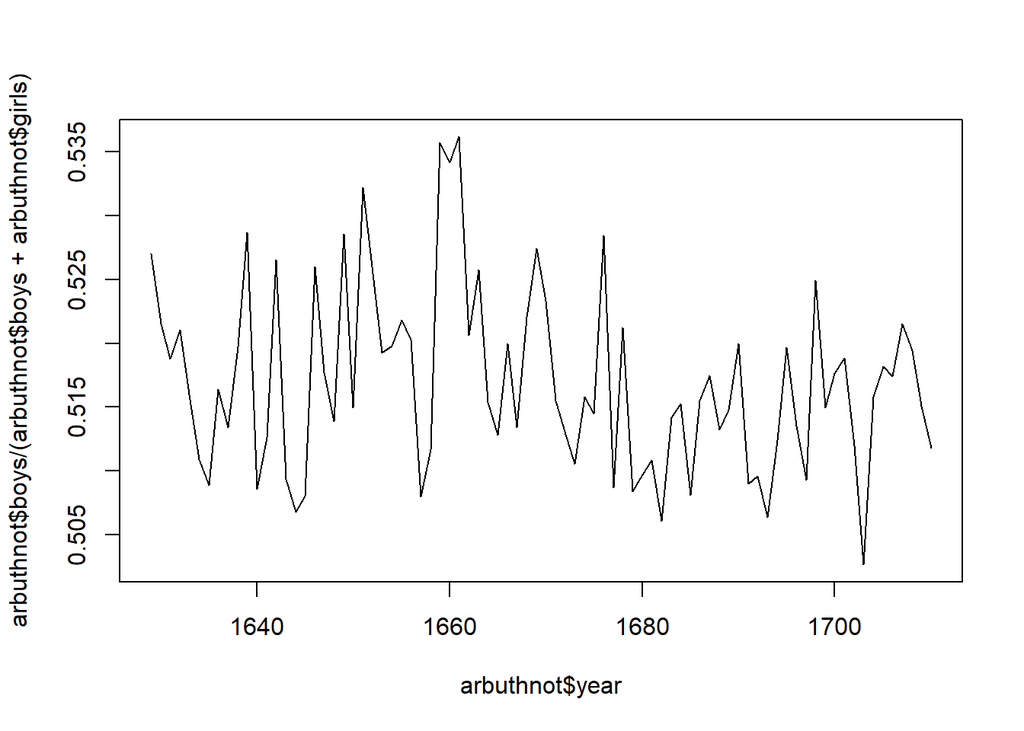

```r
plot(x = arbuthnot$year, y = arbuthnot$boys/(arbuthnot$boys + arbuthnot$girls), type = "l")
```

**Activities 1-4 from the On Your Own section of Lab 1 (Introduction to R & RStudio lab)**

```r
source("http://www.openintro.org/stat/data/present.R")
present
```

```
##    year    boys   girls
## 1  1940 1211684 1148715
## 2  1941 1289734 1223693
## 3  1942 1444365 1364631
## 4  1943 1508959 1427901
## 5  1944 1435301 1359499
## 6  1945 1404587 1330869
## 7  1946 1691220 1597452
## 8  1947 1899876 1800064
## 9  1948 1813852 1721216
## 10 1949 1826352 1733177
## 11 1950 1823555 1730594
## 12 1951 1923020 1827830
## 13 1952 1971262 1875724
## 14 1953 2001798 1900322
```

[output cut: 49 more lines]

1. What years are included in this data set? What are the dimensions of the data frame and what are the variable or column names?

Years included in the dataset

```r
present$year
```

```
##  [1] 1940 1941 1942 1943 1944 1945 1946 1947 1948 1949 1950 1951 1952 1953
## [15] 1954 1955 1956 1957 1958 1959 1960 1961 1962 1963 1964 1965 1966 1967
## [29] 1968 1969 1970 1971 1972 1973 1974 1975 1976 1977 1978 1979 1980 1981
## [43] 1982 1983 1984 1985 1986 1987 1988 1989 1990 1991 1992 1993 1994 1995
## [57] 1996 1997 1998 1999 2000 2001 2002
```

Dimensions on the data frame

```r
dim(present)
```

```
## [1] 63  3
```

Variable or Column Names

```r
names(present)
```

```
## [1] "year"  "boys"  "girls"
```

2. How do these counts compare to Arbuthnot’s? Are they on a similar scale?

Total number of boys and girls in Present datset = **231809422**

Total number of boys and girls in Arbuthnot datset = **938223**

Arbuthnot’s datset’s average boys to girls ratio = **1.070748**

Present datset’s average boys to girls ratio = **1.051353**

Boys to girl ratio seem to be constant, there is common theme across both data sets which is number of boys is greater than the number of girls. From below calculation it clearly indicates the average ratio of boys to girls is almost constant across 2 dataset (Arbuthnot and Present), difference of 0.02 in average.

As far as scale is concerned the Present data set is in millions, where as the Arbuthnot’s data is in thousands that too less than 10,000. Total count of number of girls and boys in Present dataset is *247** time that of the total number bos and girls in Arbuthnot’s dataset.

arbuthnot boys to girls ratio

```r
arbuthnot$boys / arbuthnot$girls
```

```
##  [1] 1.114243 1.089971 1.078011 1.088017 1.065923 1.044606 1.036120
##  [8] 1.067752 1.055194 1.082189 1.121656 1.034884 1.051923 1.112016
## [15] 1.038120 1.027521 1.032661 1.109867 1.073529 1.057215 1.121267
## [22] 1.061719 1.137676 1.107290 1.080095 1.082416 1.091371 1.084565
## [29] 1.032533 1.047793 1.153901 1.146905 1.156075 1.085988 1.108584
## [36] 1.063369 1.052697 1.083121 1.055242 1.092266 1.116143 1.097744
## [43] 1.064016 1.052778 1.043112 1.065354 1.059647 1.120575 1.035467
## [50] 1.088679 1.034100 1.039530 1.044237 1.024466 1.058536 1.062860
## [57] 1.032846 1.064054 1.072498 1.054359 1.060974 1.083128 1.036526
## [64] 1.039092 1.025792 1.050850 1.081931 1.055748 1.037981 1.104904
## [71] 1.061594 1.073219 1.078254 1.048981 1.010673 1.065354 1.075460
## [78] 1.072132 1.090022 1.080808 1.062331 1.048299
```

Average of arbuthnot boys to girls ratio

```r
mean(arbuthnot$boys / arbuthnot$girls)
```

```
## [1] 1.070748
```

present boys to girl ratio

```r
present$boys / present$girls
```

```
##  [1] 1.054817 1.053969 1.058429 1.056767 1.055757 1.055391 1.058698
##  [8] 1.055449 1.053820 1.053760 1.053716 1.052078 1.050934 1.053399
## [15] 1.051460 1.050742 1.051286 1.050672 1.049374 1.049480 1.048873
## [22] 1.050057 1.047948 1.052717 1.047188 1.051137 1.048540 1.049964
## [29] 1.053417 1.052997 1.054719 1.051845 1.051271 1.052129 1.054797
## [36] 1.053605 1.052538 1.052569 1.052657 1.051749 1.052837 1.051615
## [43] 1.050597 1.051976 1.050199 1.052061 1.050876 1.050000 1.049991
## [50] 1.049720 1.049676 1.045849 1.050017 1.049955 1.047877 1.048928
## [57] 1.047062 1.047643 1.047190 1.048791 1.047998 1.045686 1.047986
```

Average of present boys to girl ratio

```r
mean(present$boys / present$girls)
```

```
## [1] 1.051353
```

Total number of girls and boys for arbuthnot

```r
sum(arbuthnot$boys) + sum(arbuthnot$girls)
```

```
## [1] 938223
```

Total number of girls and boys for present

```r
sum(present$boys) + sum(present$girls)
```

```
## [1] 231809422
```

Scale ratio in total boys and girls count between arbuthnot and present

```r
(sum(present$boys) + sum(present$girls))/(sum(arbuthnot$boys) + sum(arbuthnot$girls))
```

```
## [1] 247.0728
```

3. Make a plot that displays the boy-to-girl ratio for every year in the data set. What do you see? Does Arbuthnot’s observation about boys being born in greater proportion than girls hold up in the U.S.? Include the plot in your response.

Plot that displays the boy-to-girl ratio for every year in the data set

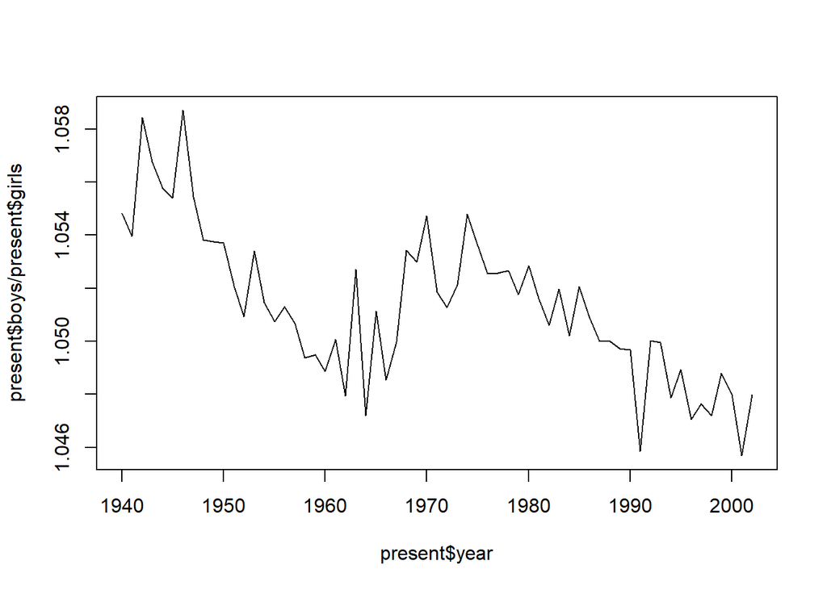

```r
plot(x=present$year, y=present$boys/present$girls, type="l")
```

Boys to girl ratio almost remains constant.

```r
present$boys > present$girls
```

```
##  [1] TRUE TRUE TRUE TRUE TRUE TRUE TRUE TRUE TRUE TRUE TRUE TRUE TRUE TRUE
## [15] TRUE TRUE TRUE TRUE TRUE TRUE TRUE TRUE TRUE TRUE TRUE TRUE TRUE TRUE
## [29] TRUE TRUE TRUE TRUE TRUE TRUE TRUE TRUE TRUE TRUE TRUE TRUE TRUE TRUE
## [43] TRUE TRUE TRUE TRUE TRUE TRUE TRUE TRUE TRUE TRUE TRUE TRUE TRUE TRUE
## [57] TRUE TRUE TRUE TRUE TRUE TRUE TRUE
```

```r
arbuthnot$boys > arbuthnot$girls
```

```
##  [1] TRUE TRUE TRUE TRUE TRUE TRUE TRUE TRUE TRUE TRUE TRUE TRUE TRUE TRUE
## [15] TRUE TRUE TRUE TRUE TRUE TRUE TRUE TRUE TRUE TRUE TRUE TRUE TRUE TRUE
## [29] TRUE TRUE TRUE TRUE TRUE TRUE TRUE TRUE TRUE TRUE TRUE TRUE TRUE TRUE
## [43] TRUE TRUE TRUE TRUE TRUE TRUE TRUE TRUE TRUE TRUE TRUE TRUE TRUE TRUE
## [57] TRUE TRUE TRUE TRUE TRUE TRUE TRUE TRUE TRUE TRUE TRUE TRUE TRUE TRUE
## [71] TRUE TRUE TRUE TRUE TRUE TRUE TRUE TRUE TRUE TRUE TRUE TRUE
```

As you can see in both data sets number of boys is greater than number of girls. So Arbuthnot’s observation about boys being born in greater proportion than girls hold up in the U.S.

Plot that displays the boy-to-girl ratio for every year in the Arbuthnot data set

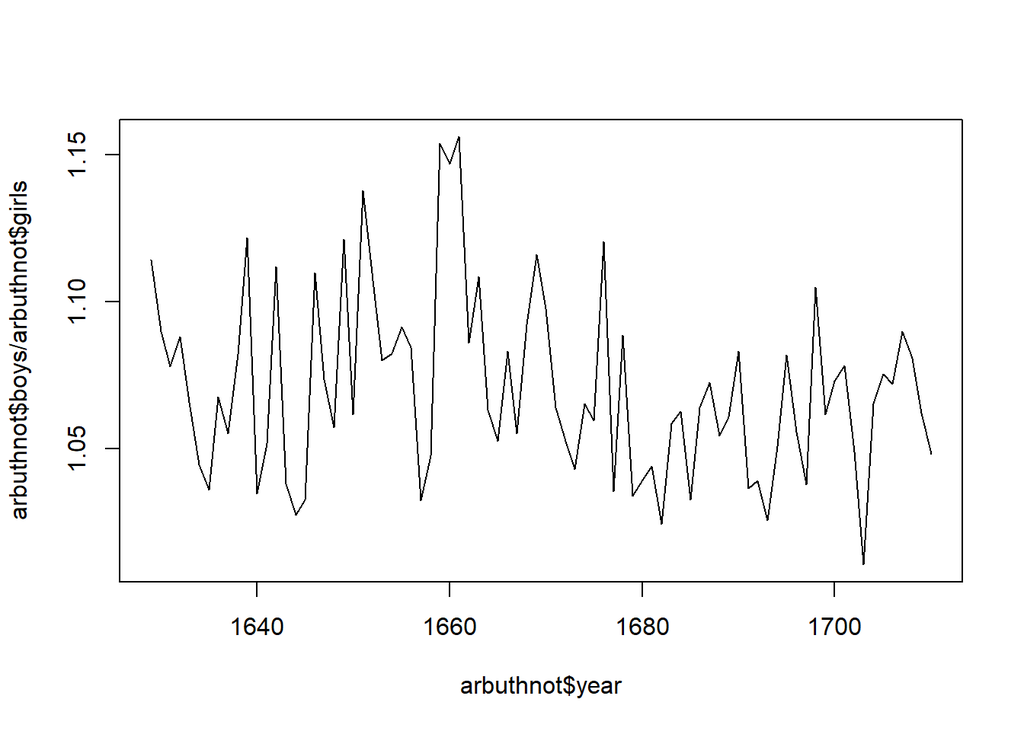

```r
plot(x=arbuthnot$year, y=arbuthnot$boys/arbuthnot$girls, type="l")
```

In what year did we see the most total number of births in the U.S.?

```r
present[which.max(present$boys + present$girls),]$year
```

```
## [1] 1961
```